# Using scRUtils for single-cell data visualisations

I-Hsuan Lin

07/29/2026

#### Package

scRUtils 0.4.2

# 1 Overview

`scRUtils` provides various utilities for visualising and functional analysis of RNA-seq data, particularly single-cell dataset. It evolved from a collection of helper functions that were used in our in-house scRNA-seq processing workflow.

The documentation of this package is divided into 5 sections:

1. [Introduction to scRUtils](https://ycl6.github.io/scRUtils/scRUtils-intro.html)
2. [General data visualisations](https://ycl6.github.io/scRUtils/basics.html)
3. [Single-cell visualisations](https://ycl6.github.io/scRUtils/singleCell.html)
4. [Markers and DEGs](https://ycl6.github.io/scRUtils/markers.html)
5. [Demo datasets](https://ycl6.github.io/scRUtils/demoData.html)

This vignette (#3) will demonstrate functions specific for single-cell datasets.

# 2 Load packages

To use `scRUtils` and relevant packages in a R session, we load them using the `library()` command.

```r
library(scRUtils)

library(cowplot)
library(ggplot2)
library(scater)
```

# 3 General visualisations

## 3.1 Plot expression of groups of cells in boxplot

The `plotBox()` function produces a boxplot to show the expression levels of selected genes in groups of cells. It requires a `SingleCellExperiment` object (argument `sce`) and `features` argument denoting the genes to plot. The `group_by` argument specify how the cells are to be grouped. If none were provided, all cells will be grouped into 1 group.

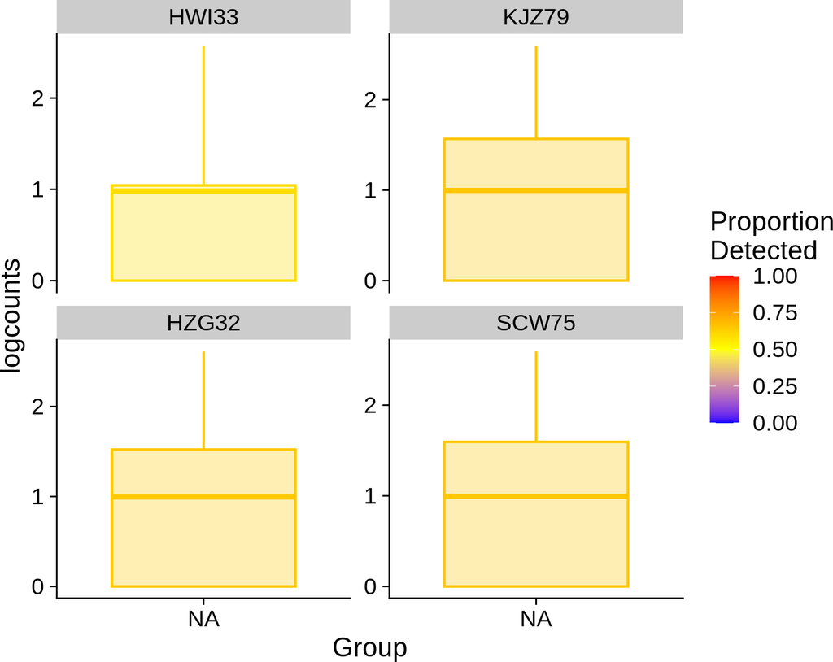

```r
data(sce)

# All cells in 1 group
plotBox(sce, features = rownames(sce)[10:13])
```

By default, the boxes are coloured by the fraction of cells in a group expressing the given gene. We can use `color_by` to colour by cell groups.

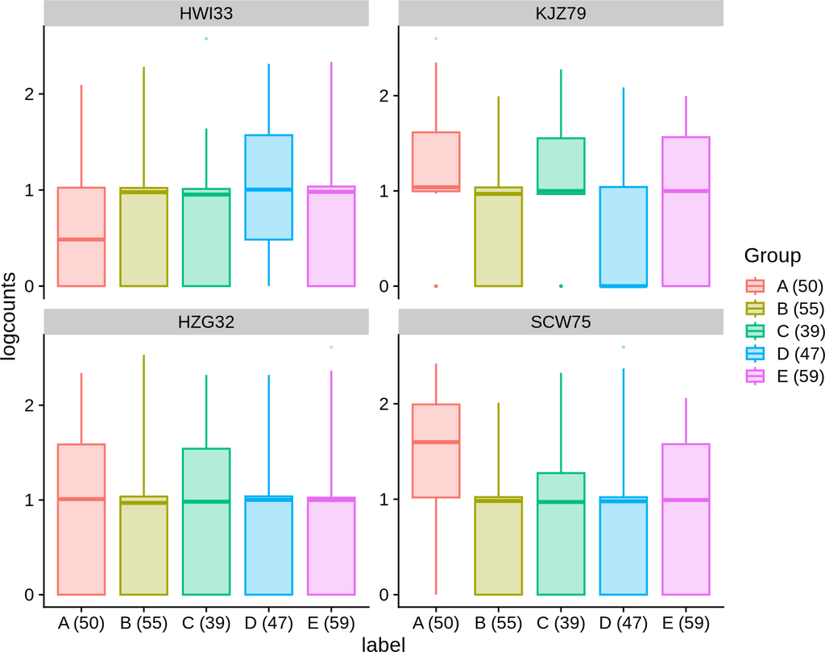

```r
# Group cells by "label", colour by cell groups, and change theme base size
plotBox(sce, features = rownames(sce)[10:13], group_by = "label",
        color_by = "Group", theme_size = 14)
```

It is also possible to show the results in a subset of cell using the `columns` argument.

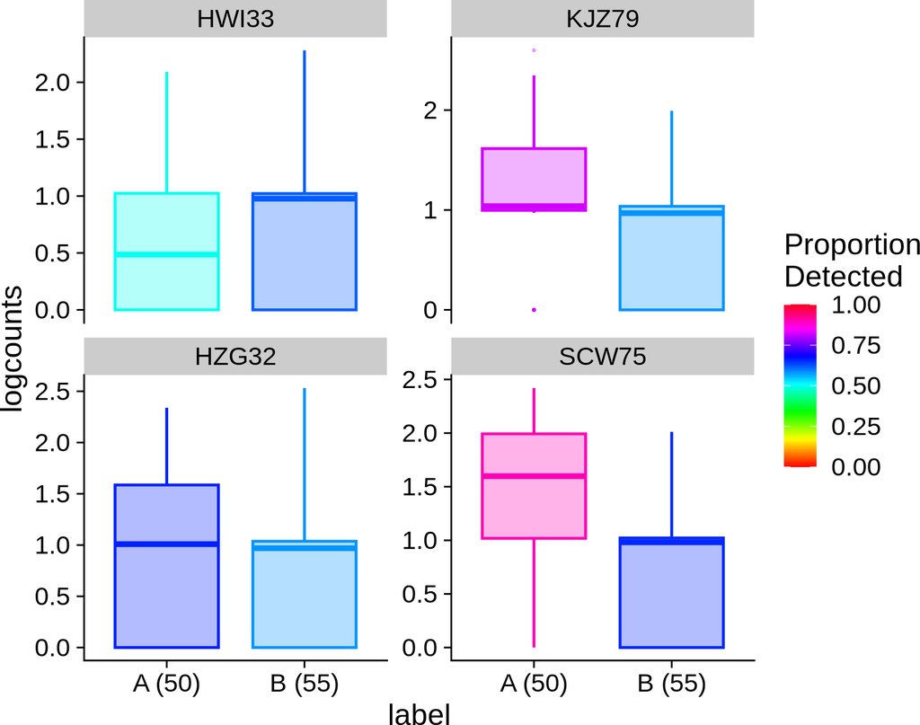

```r
# Show cells of labels A and B only and change colour palette
keep <- sce$label %in% c("A","B")
plotBox(sce, features = rownames(sce)[10:13], group_by = "label",
    box_colors = rainbow(50), columns = keep)
```

A maximum of 2 grouping terms can be provided in the `group_by` argument, and cells will be grouped accordingly. Given the number of possible cell groups increases when combining 2 terms, we can adjust the number of columns to show in the plot, the size and angle of the x-axis labels, and theme base size.

```r
table(sce$label, sce$CellType)
```

```
##
##     Type 1 Type 2 Type 3 Type 4 Type 5
##   A     49      0      0      0      1
##   B      0     55      0      0      0
##   C      0      0     38      1      0
##   D      0      0      0     46      0
##   E      0      0      1      0     58
```

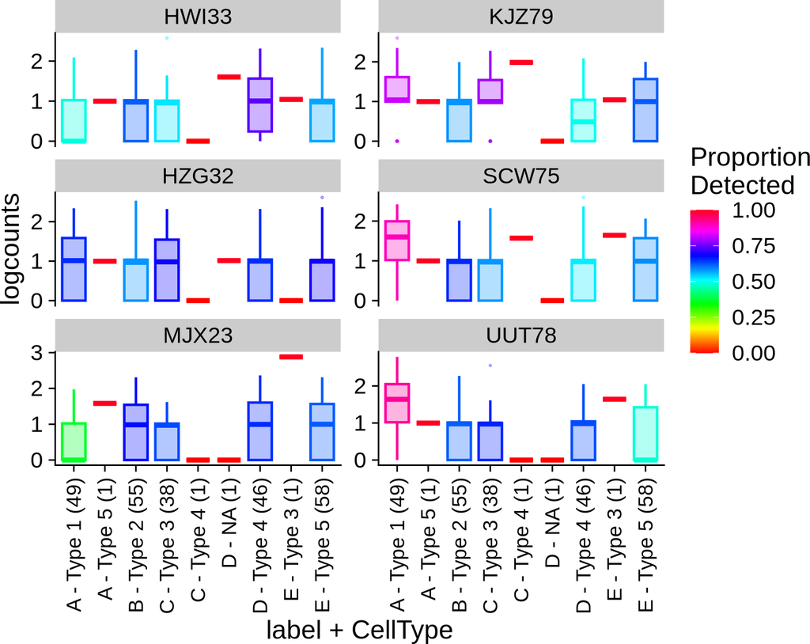

```r
# Group cells by "label" and "CellType", showing 2 features per row
plotBox(sce, features = rownames(sce)[10:15],
    group_by = c("label","CellType"), box_colors = rainbow(50),
    facet_ncol = 2, x.text_angle = 90, x.text_size = 14)
```

## 3.2 Plot G2M against G1 scores from `cyclone` results

The `plotCyclone()` function produces a scatter plot to show the predicted G1 and G2M scores and cell cycle phases of single cells after performing classification using `cyclone()` from the *scran* package.

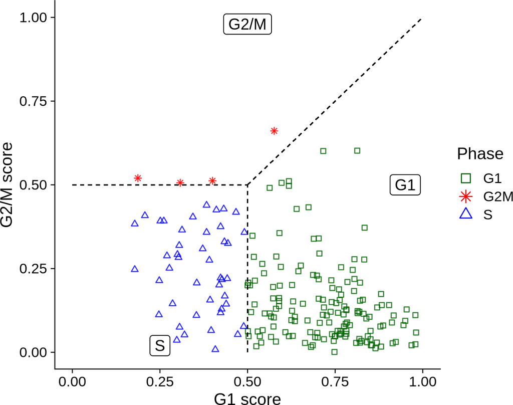

```r
data(phases_assignments)

plotCyclone(phases_assignments)
```

## 3.3 Plot expression frequency against mean counts

The `plotExprsFreqVsMean()` function uses `plotRowData()` from the *scater* package to produce a scatter plot of expression frequency against mean counts by using per- feature quality control metrics produced by `addPerCellQC()` or `perFeatureQCMetrics()` from the *scuttle* package and stored in `rowData` of the `SingleCellExperiment` input.

The original function of the same name can be found in the legacy scater package (*archive-scater*) and is now deprecated.

```
## The `method` was set to "gam", but mgcv is not installed.
## ! Falling back to `method = "lm"`.
## ℹ Install mgcv or change the `method` argument to resolve this issue.
```

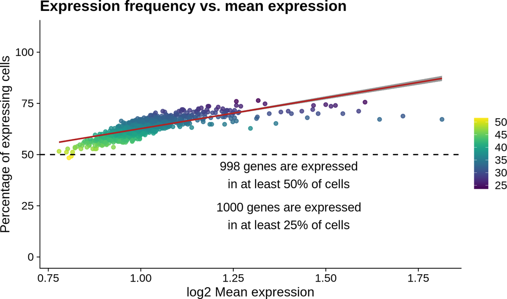

```r
plotExprsFreqVsMean(sce, title = "Expression frequency vs. mean expression")
```

## 3.4 Plot logcounts variance against logcounts mean

The `plotVarianceVsMean()` function calculates the per-feature mean and variance using normalised counts (accessible via `logcounts()`) from a `SingleCellExperiment` object, and returns a logcounts mean-variance scatter plot.

When the `rowData` slot of the `SingleCellExperiment` input contains QC metrics for features that were returned by `addPerCellQC()` or `perFeatureQCMetrics()`, this function will use `detected` (percentage of expressed features above the detection limit) to calculate `pct_dropout` (percentage of dropouts) and colour the points accordingly.

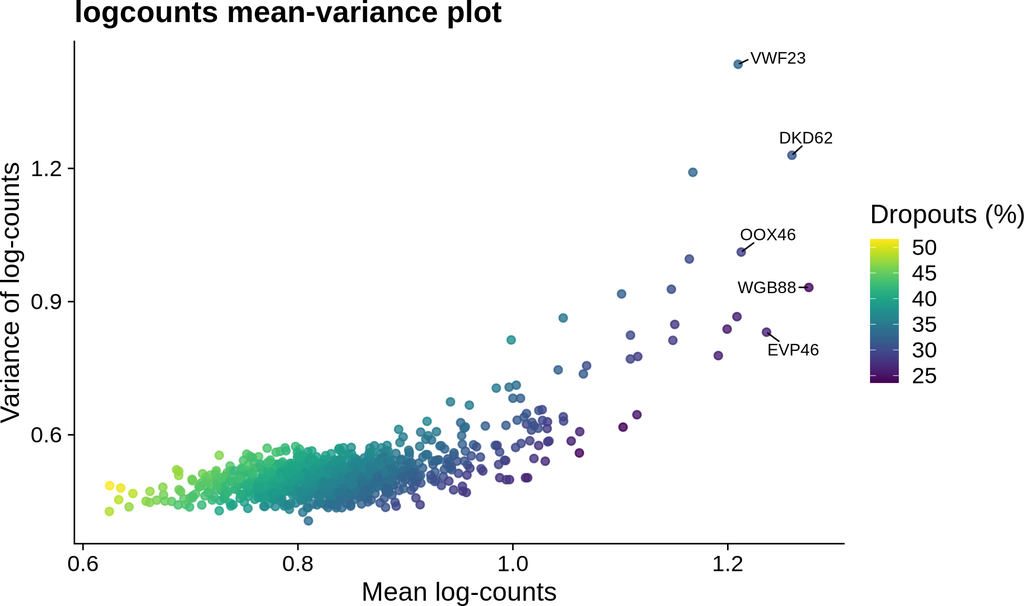

```r
plotVarianceVsMean(sce, title = "logcounts mean-variance plot")
```

## 3.5 Plot variance modelling results

The `plotVariableFeature()` function requires a `SingleCellExperiment` object (argument `sce`) and the resulting DataFrame (argument `var`) after performing variance modelling, such as `modelGeneVar()` from the *scran* package, and produces a mean-variance scatter plot.

In addition to the two required inputs, if `rowData(sce)` has `is_pass` and/or `is_ambient` columns containing logical values (i.e. `TRUE` and `FALSE`), denoting if a gene passed QC or if its expression is attributable to ambient contamination, the resulting figure will show the genes in different shapes.

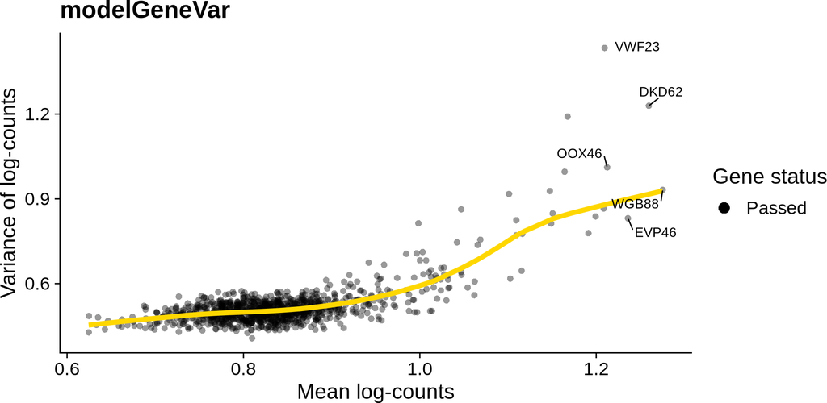

```r
var <- metadata(sce)[["modelGeneVar"]]

plotVariableFeature(sce, var, top_n = 5, title = "modelGeneVar")
```

One can supply the `hvg` argument a character vector containing highly variable genes to be coloured in red.

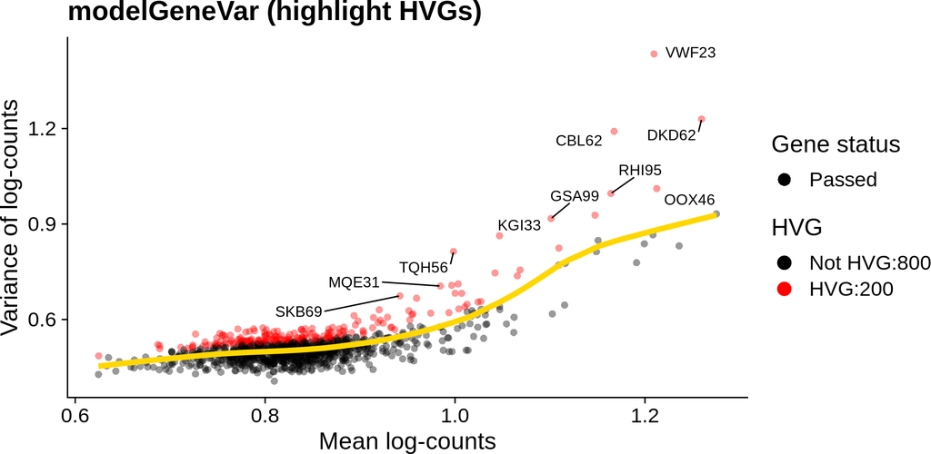

```r
hvg <- metadata(sce)[["HVG"]]

plotVariableFeature(sce, var, hvg, title = "modelGeneVar (highlight HVGs)")
```

## 3.6 Plot distribution of approximate silhouette widths

The `plotSilhouette()` function produces a violin scatter plot to show the distribution of the approximate silhouette width across cells in each cluster. It uses `approxSilhouette()` from the *bluster* package’ to calculate the silhouette widths using an approximate approach.

Using the information stored in the returned DataFrame, it:

- prints the descriptive statistics of approximate silhouette widths.
- calculates the percentage of cells assigned to the closest cluster and prints the result when `printDiff = TRUE`.
- creates a violin scatter plot to show the distribution of the approximate silhouette width when `plot = TRUE`.

These information can allow users to identify poorly separate clusters quickly.

```
## Silhouette width summary:
```

```
##    Min. 1st Qu.  Median    Mean 3rd Qu.    Max.
## 0.03618 0.07854 0.09546 0.09978 0.11718 0.18600
## # A tibble: 5 × 2
##   cluster `% Different`
##   <chr>           <dbl>
## 1 A                   0
## 2 B                   0
## 3 C                   0
## 4 D                   0
## 5 E                   0
```

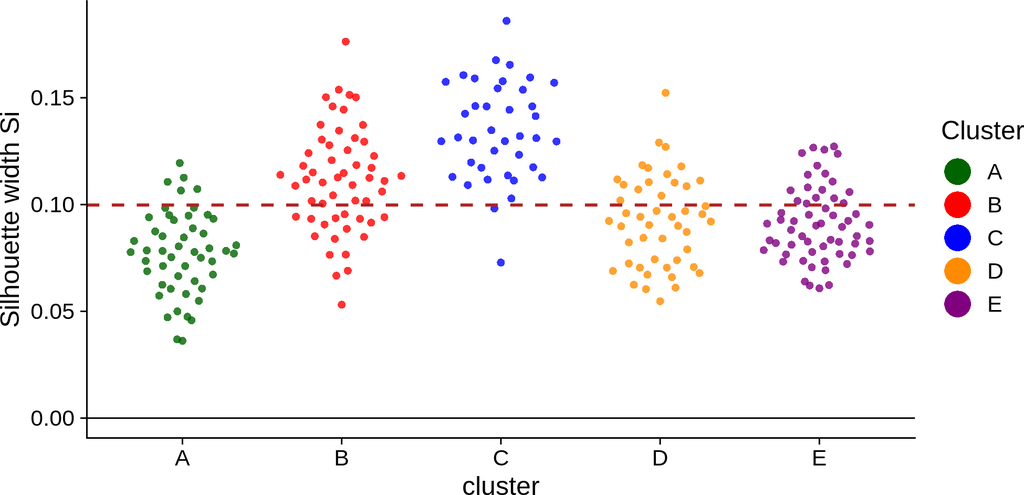

```r
mat <- reducedDim(sce, "PCA")
plotSilhouette(mat, sce$label)
```

## 3.7 Create QC plots from `findDoubletClusters` results

The `plotqcDoubletClusters` function produces QC plots to aid deciding potential doublet clusters after running `findDoubletClusters()` from the *scDblFinder* package. By setting the `qc_plot` argument, it returns:

0. The default, a compound figure.
1. A scatter plot of median number of significant genes (`median.de`) against number of significant genes (`num.de`).
2. A barplot showing the proportion of cells in each of the query cluster (`prop`).
3. A scatter plot of ratio of the median library sizes for the second source cluster (`lib.size2`) against first source cluster (`lib.size1`).

The example below produces a compound figure.

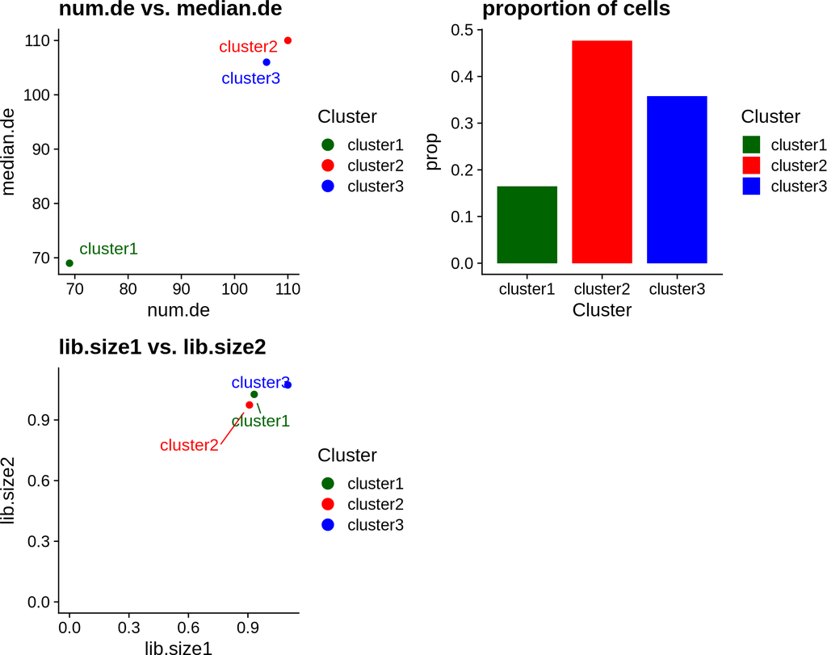

```r
data(dbl_results)

plotqcDoubletClusters(dbl_results, text_size = 5, theme_size = 16)
```

Or set `qc_plot` to 1 to produce just the `median.de` against `num.de` scatter plot.

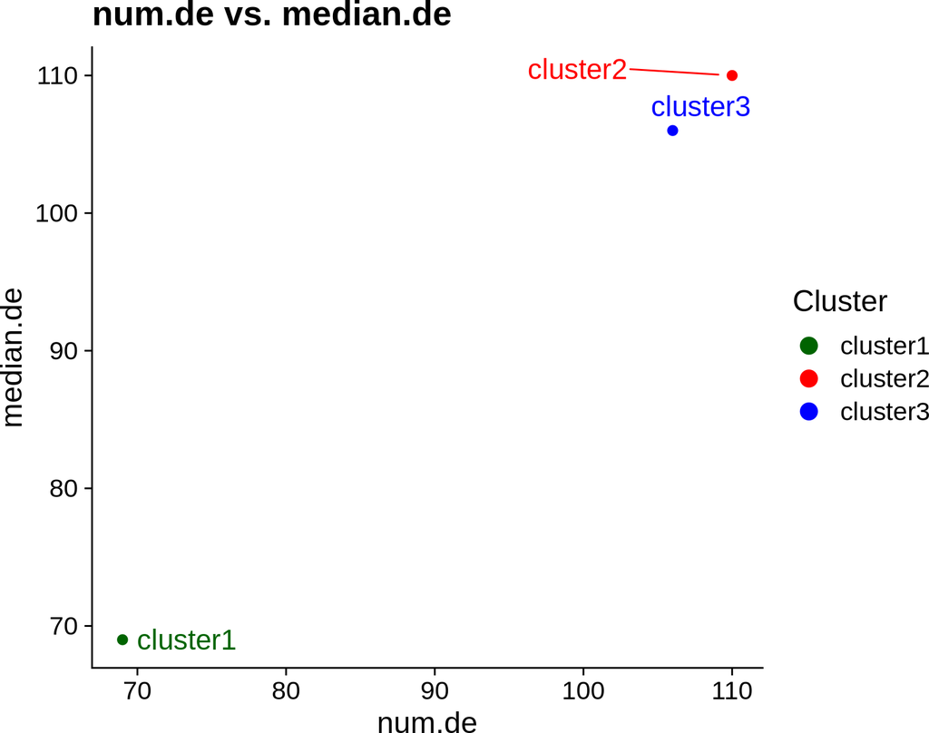

```r
plotqcDoubletClusters(dbl_results, qc_plot = 1)
```

# 4 UMAP/TSNE projection

## 4.1 Add labels to reduced dimension plots

The `add_label()` function is designed to be used with `plotReducedDim()` from the *scater* package without specifying text label (i.e. via `text_by`). Then use `add_label()` to place labels centrally. The repel-away-from-center behaviour in `plotReducedDim()` should be fixed in *scater* v1.23.5.

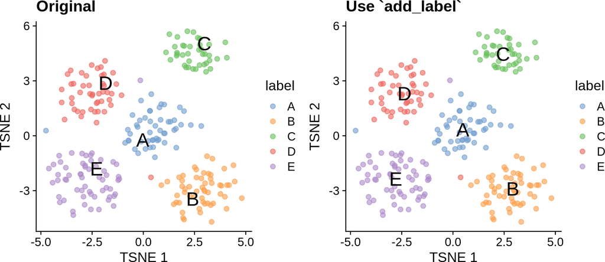

```r
p1 <- plotReducedDim(sce, "TSNE", colour_by = "label", text_by = "label",
                     text_size = 8, theme_size = 16) + ggtitle("Original")
p2 <- plotReducedDim(sce, "TSNE", colour_by = "label", theme_size = 16) +
        add_label(sce, "TSNE") + ggtitle("Use `add_label`")

plot_grid(p1, p2)
```

## 4.2 Colour cells in a TSNE or UMAP

The `plotProjection()` function uses `plotReducedDim()` from the *scater* package to show cells on a pre-calculated low-dimensional projection (such as UMAP or t-SNE) and colour by a choosen cell-specific feature or level of gene expression.

The function adds aesthetic, such as point colours, legend controls, title and subtitles, to the final figure. It uses `add_label()` to label cells when `text_by` is used.

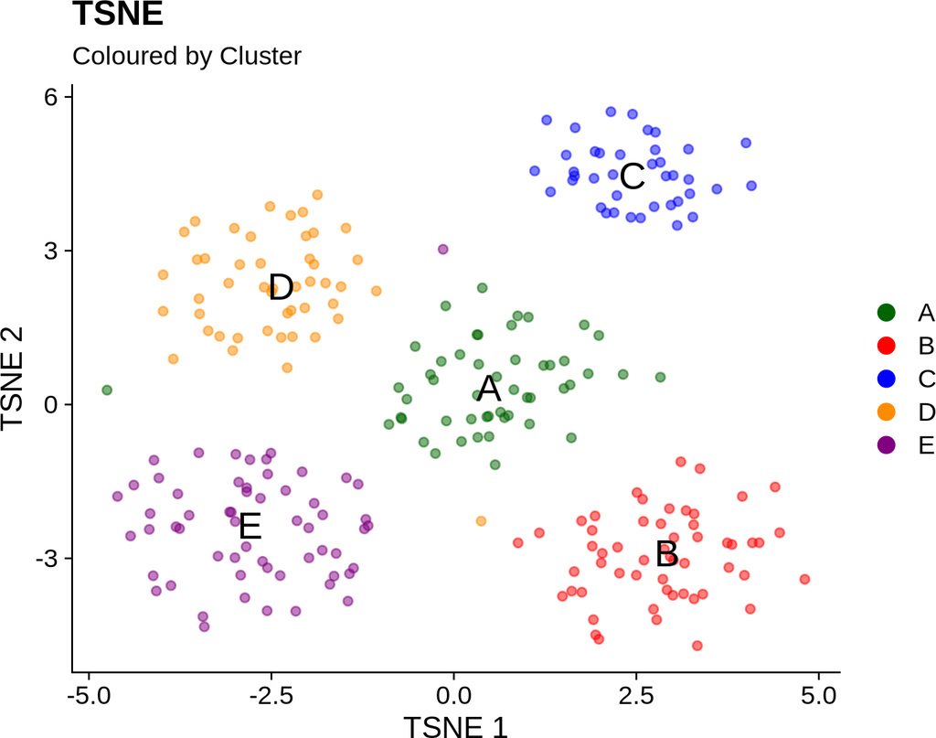

```r
plotProjection(sce, "label", dimname = "TSNE", text_by = "label",
               feat_desc = "Cluster")
```

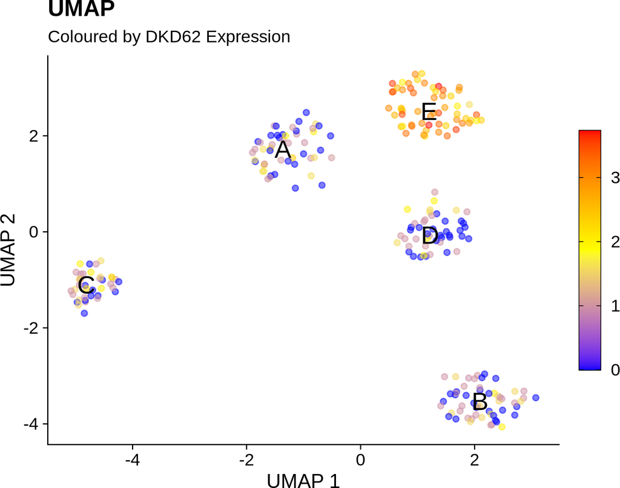

```r
plotProjection(sce, "DKD62", dimname = "UMAP", text_by = "label",
               feat_desc = "DKD62 Expression", guides_barheight = 15)
```

## 4.3 Coloure cells in TSNE or UMAP side-by-side

The `plotProjections()` function make use of `plotProjection()` to show cells on two pre- calculated low-dimensional projection (such as UMAP and t-SNE) in a compound figure using `plot_grid()` from the *cowplot* package.

It also uses `get_legend()` from *cowplot* to produce a shared legend and places it at the desired position as specified by `legend_pos`.

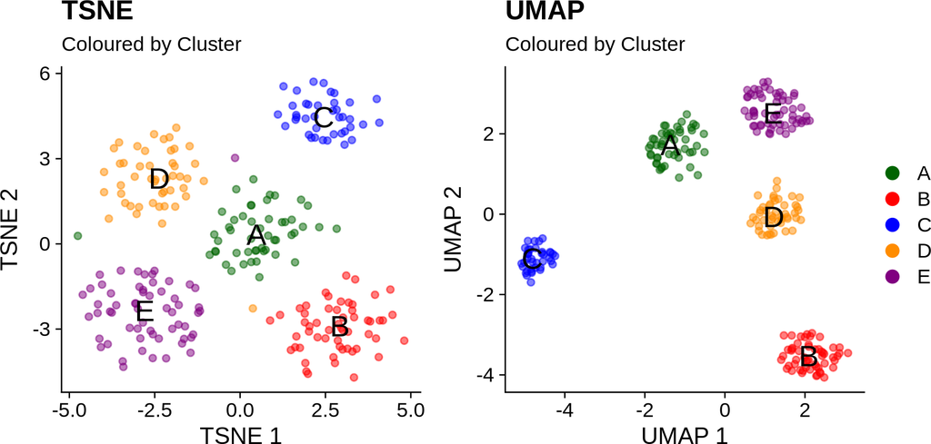

```r
plotProjections(sce, "label", dimname = c("TSNE", "UMAP"),
                text_by = "label", feat_desc = "Cluster", point_size = 2)
```

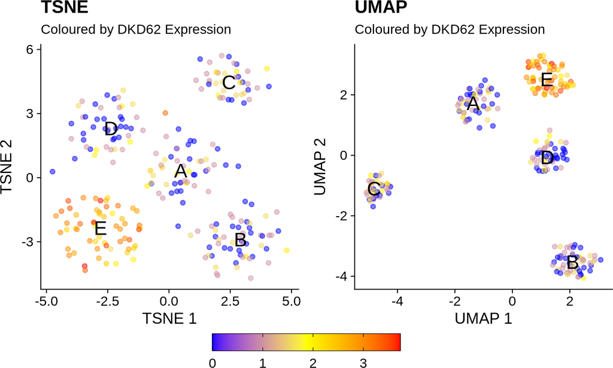

```r
plotProjections(sce, "DKD62", dimname = c("TSNE", "UMAP"),
                text_by = "label", feat_desc = "DKD62 Expression",
                point_size = 2, legend_pos = "bottom", guides_barwidth = 15,
                rel_heights = c(10, 1))
```

## 4.4 Show ligand-receptor gene expression levels in a TSNE or UMAP

The `plotReducedDimLR()` function produces a figure to show the levels of gene expression of a ligand-receptor pair on a pre-calculated low-dimensional projection (such as UMAP or t-SNE).

The function is based on `plotReducedDim()` from the *scater* package, and uses `new_scale_colour()` from the *ggnewscale* package to add an additional `layer` where a second `geom` uses another colour scale to show the expression intensity of a second gene.

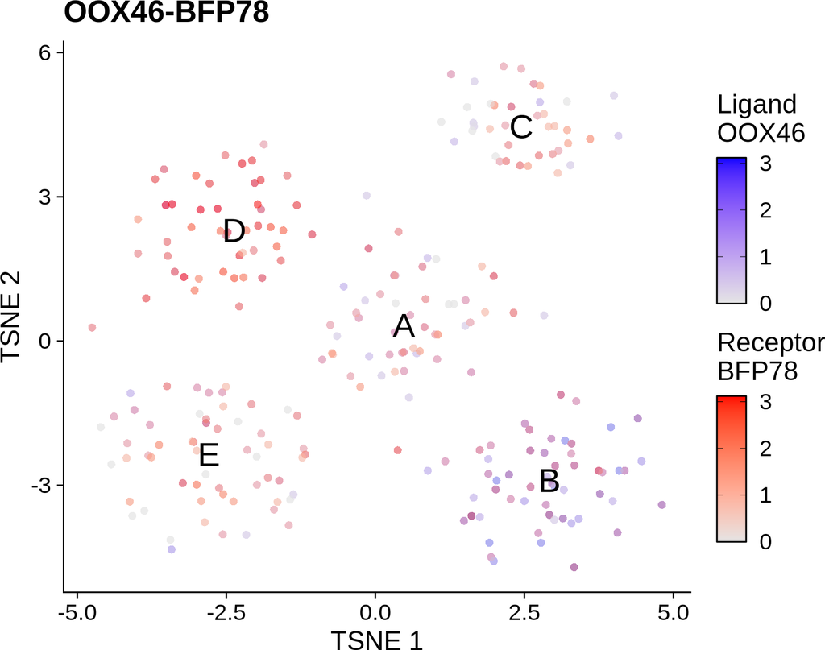

```r
plotReducedDimLR(sce, "TSNE", c("OOX46", "BFP78"), text_by = "label")
```

Even though `plotReducedDimLR()` was designed initially to show ligand-receptor expression, by changing the `lr_desc` and `lr_sep` arguments, one can also use this function to show the expression of two genes, that could be expressed in a mutually exclusive fashion, or specific to certain cell clusters or cell types.

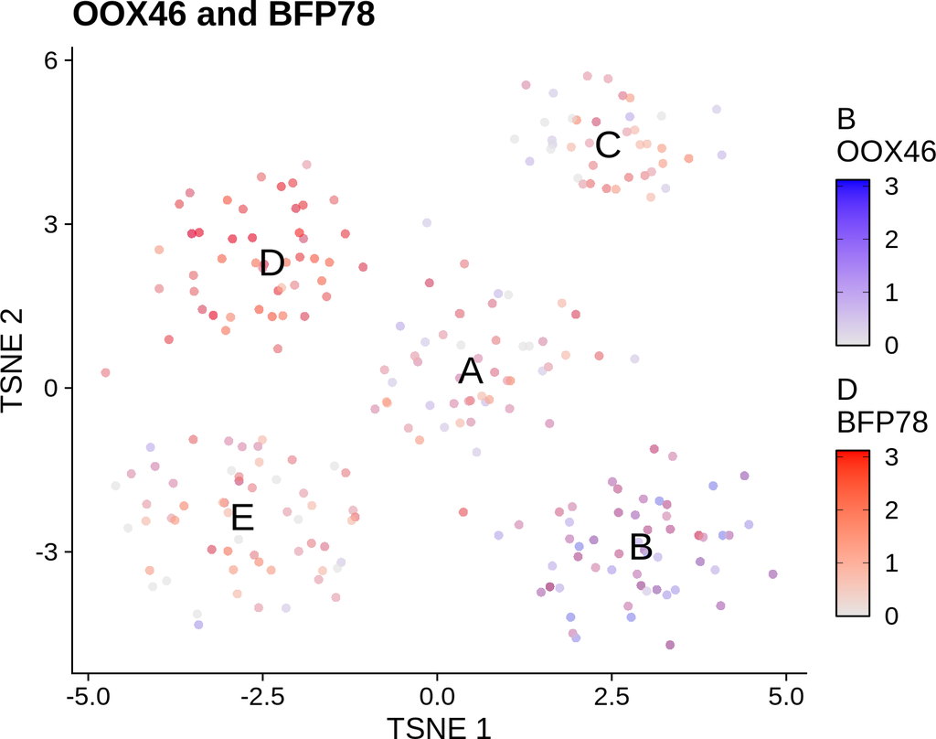

```r
plotReducedDimLR(sce, "TSNE", c("OOX46", "BFP78"), lr_desc = c("B", "D"),
                 lr_sep = " and ", text_by = "label")
```

If it is too difficult to visualise the gene expression with two colour scales on the same figure, one can use `oneplot = FALSE` to create a compound figure with 2 sub-plots, each showing their respective colours.

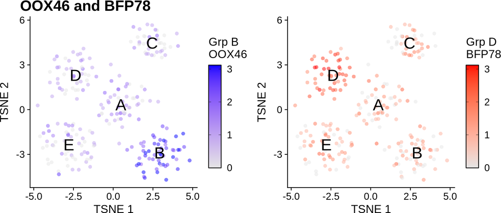

```r
plotReducedDimLR(sce, "TSNE", c("OOX46", "BFP78"),
                 lr_desc = c("Grp B", "Grp D"), lr_sep = " and ",
         text_by = "label", guides_barheight = 10, theme_size = 16,
         oneplot = FALSE)
```